# Complemento · Exploración de microalgas del río Gaira

- Mostrar todo el código
- Ocultar todo el código
- Ver el código fuente

Taller 6. Exploración gráfica multivariada — material complementario

Fecha de publicación

20 de octubre de 2026

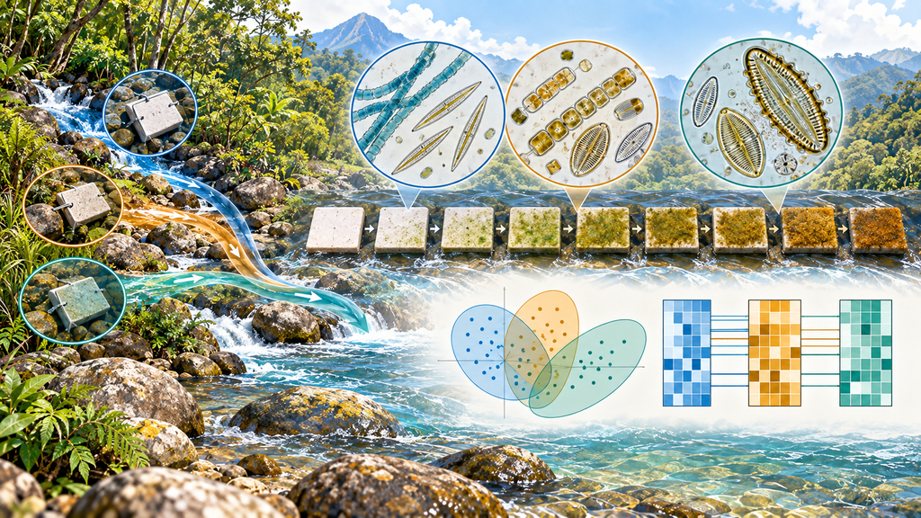

Este complemento aplica el mapa de exploración del Taller 6 a un caso real con las **tres matrices** de una base multivariada: factores (F), variables ambientales (X) y especies (Y). Los datos son microalgas perifíticas colonizando sustratos artificiales en tres tributarios del río Gaira, Sierra Nevada de Santa Marta, durante 8 semanas (Acta Biol. Colomb. 20(2), 2015; Osorio Ávila et al., 2015). Es la misma base que se ordena en los Talleres 7 (PCA), 8 (NMDS y CA) y 9 (RDA y CCA).

**Código**

```r
# Librerías requeridas
library(tidyverse)
library(readxl)
library(kableExtra)
library(corrplot)

# Paleta de tributarios
col_trib <- c(T1 = "#2C6FB7", T2 = "#E3A33B", T3 = "#3E9C8F")

# Panel de la diagonal para pairs(): histograma
panel_hist <- function(x, ...) {
  usr <- par("usr"); on.exit(par(usr = usr))
  par(usr = c(usr[1:2], 0, 1.5))
  h <- hist(x, plot = FALSE)
  rect(h$breaks[-length(h$breaks)], 0,
       h$breaks[-1],
       h$counts / max(h$counts),
       col = "#9DBFE3", border = "white")
}

# Panel superior para pairs(): r de Pearson
panel_r <- function(x, y, ...) {
  usr <- par("usr"); on.exit(par(usr = usr))
  par(usr = c(0, 1, 0, 1))
  r <- cor(x, y)
  text(0.5, 0.5, sprintf("%.2f", r),
       cex = 0.9 + 1.5 * abs(r))
}
```

## 1. Las tres matrices

La base `Microalgas.xlsx` ya está en formato ancho: 24 muestras (3 tributarios × 8 visitas semanales de colonización) con 10 variables ambientales y 21 géneros. Se separan las tres matrices **por nombre de columna** y se corrigen cinco nombres de género mal escritos en el archivo original.

**Código**

```r
# Leer la hoja de Excel y corregir nombres de género
alg <- read_excel("Microalgas.xlsx", sheet = "Microalgas") %>%
  rename(Fragilaria = Fragillaria,
         Nitzschia  = Nitzchia,
         Surirella  = Surilella,
         Gyrosigma  = Girosigma,
         Achnanthes = Achnantes) %>%
  mutate(Tributario = factor(Tributario),
         Visita     = factor(as.integer(sub(".*\\.", "", Cod))))   # T1.3 → 3

# Matriz de factores (F), ambiental (X) y de especies (Y)
F_alg <- alg %>% select(Cod, Tributario, Visita)
X_alg <- alg %>% select(Amonio:Temp)
Y_alg <- alg %>% select(Fragilaria:Pinnularia)

# Las tres matrices deben tener las mismas filas
c(F = nrow(F_alg),
  X = ncol(X_alg),
  Y = ncol(Y_alg))
```

```
 F  X  Y
24 10 21
```

F tiene 24 filas, X tiene 10 variables ambientales y Y tiene 21 géneros.

## 2. Relaciones dentro de la matriz ambiental

**Pregunta:** ¿Qué variables ambientales cambian juntas en los tributarios?

### Correlograma de elipses

**Código**

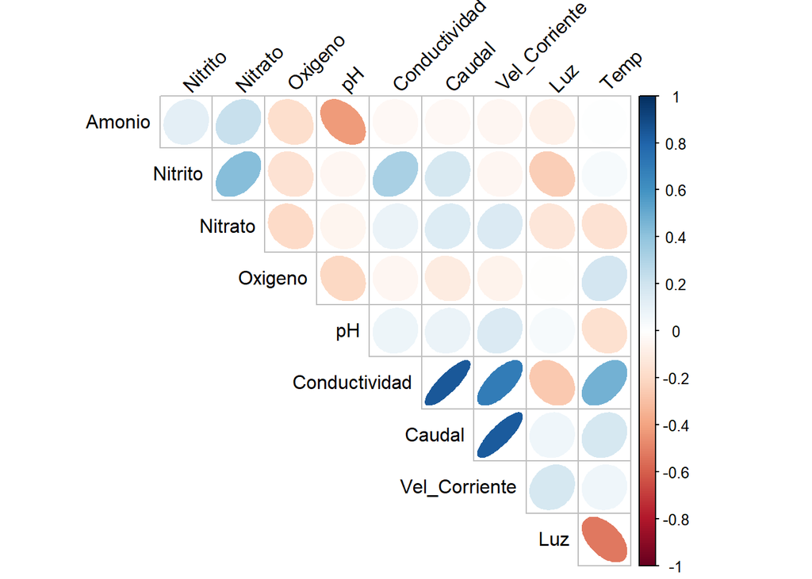

Figura 1: Correlograma de elipses de las 10 variables ambientales de microalgas (r de Pearson). Azul: correlación positiva; rojo: negativa; elipses más estrechas indican correlaciones más fuertes.

```r
# Matriz de correlación de Pearson de X
r_X <- cor(X_alg)

# Correlograma de elipses
corrplot(r_X, method = "ellipse",
         type = "upper", diag = FALSE,
         tl.col = "black", tl.srt = 45)
```

Para no depender solo de la lectura visual, se listan los pares con |r| ≥ 0.4:

**Código**

```r
# Pares de variables con |r| >= 0.4, ordenados por intensidad
pares_r <- as.data.frame(as.table(r_X)) %>%
  filter(as.integer(Var1) < as.integer(Var2), abs(Freq) >= 0.4) %>%
  arrange(desc(abs(Freq))) %>%
  transmute(`Variable 1` = Var1,
            `Variable 2` = Var2, r = round(Freq, 2))

# Tabla de pares
pares_r %>%
  kbl(booktabs = TRUE) %>%
  kable_classic(full_width = F) %>%
  row_spec(0, bold = TRUE)
```

| Variable 1 | Variable 2 | r |
| --- | --- | --- |
| Conductividad | Caudal | 0.85 |
| Caudal | Vel_Corriente | 0.84 |
| Conductividad | Vel_Corriente | 0.69 |
| Luz | Temp | -0.53 |
| Conductividad | Temp | 0.47 |
| Amonio | pH | -0.43 |
| Nitrito | Nitrato | 0.42 |

Conductividad, caudal y velocidad de corriente forman un **bloque** (r = 0.69 a 0.85). Fuera de él, se destacan la relación negativa entre luz y temperatura (r = -0.53) y entre amonio y pH (r = -0.43).

### Pares: forma de la relación

El correlograma da el signo y la intensidad, pero no la **forma**. La figura de pares añade histogramas en la diagonal, el r de Pearson arriba y una curva suavizada (loess) abajo.

**Código**

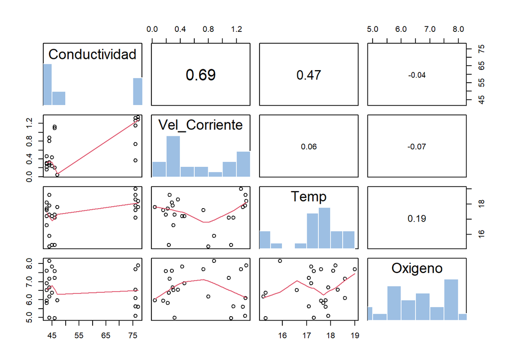

Figura 2: Pares de cuatro variables ambientales de microalgas: histogramas (diagonal), r de Pearson (arriba) y suavizado loess (abajo).

```r
# Panel de la diagonal: histograma
panel_hist <- function(x, ...) {
  usr <- par("usr"); on.exit(par(usr = usr))
  par(usr = c(usr[1:2], 0, 1.5))
  h <- hist(x, plot = FALSE)
  rect(h$breaks[-length(h$breaks)], 0,
       h$breaks[-1], h$counts / max(h$counts),
       col = "#9DBFE3", border = "white")
}

# Panel superior: r de Pearson, con tamaño proporcional a |r|
panel_r <- function(x, y, ...) {
  usr <- par("usr"); on.exit(par(usr = usr))
  par(usr = c(0, 1, 0, 1))
  r <- cor(x, y)
  text(0.5, 0.5, sprintf("%.2f", r), cex = 0.9 + 1.5 * abs(r))
}

# Figura de pares
pairs(X_alg[, c("Conductividad", "Vel_Corriente", "Temp", "Oxigeno")],
      diag.panel = panel_hist, upper.panel = panel_r,
      lower.panel = panel.smooth)
```

El histograma de la conductividad muestra **dos grupos de valores** separados. Antes de interpretar el bloque como una relación entre variables, conviene revisar si se trata de una diferencia entre tributarios:

**Código**

```r
# Correlación conductividad–caudal dentro de cada tributario y con todos los datos
r_cc <- bind_rows(
  alg %>% group_by(Tributario) %>%
    summarise(n = n(), r = cor(Conductividad, Caudal)) %>%
    mutate(Tributario = as.character(Tributario)),
  tibble(Tributario = "Todos", n = nrow(alg),
         r = cor(alg$Conductividad, alg$Caudal))) %>%
  mutate(r = round(r, 2))

# Tabla de correlaciones
r_cc %>%
  kbl(booktabs = TRUE) %>%
  kable_classic(full_width = F) %>%
  row_spec(0, bold = TRUE)
```

| Tributario | n | r |
| --- | --- | --- |
| T1 | 8 | 0.02 |
| T2 | 8 | 0.11 |
| T3 | 8 | 0.24 |
| Todos | 24 | 0.85 |

**Código**

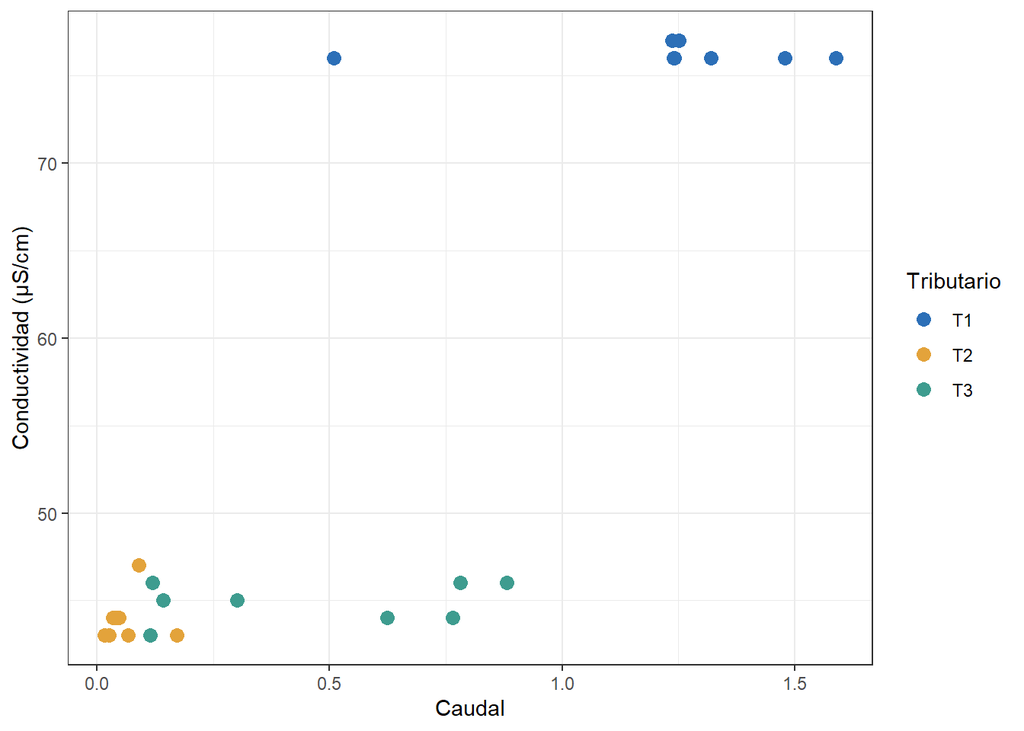

Figura 3: Conductividad frente a caudal, por tributario. La correlación global surge de la separación entre T1 y los otros dos tributarios.

```r
# Dispersión coloreada por tributario
ggplot(alg, aes(x = Caudal,
                y = Conductividad,
                color = Tributario)) +
  geom_point(size = 3) +
  scale_color_manual(values = col_trib) +
  labs(x = "Caudal", y = "Conductividad (μS/cm)") +
  theme_bw()
```

**ImportanteUna correlación puede ser una diferencia entre grupos**

Con los 24 datos, r = 0.85; dentro de cada tributario, r va de 0.02 a 0.24. La conductividad y el caudal no varían juntos semana a semana: el bloque aparece porque T1 tiene, a la vez, más conductividad y más caudal que T2 y T3. Es una diferencia entre tributarios disfrazada de correlación.

**TipVersión en ggplot2**

El correlograma también se puede construir con `ggplot2`, lo que facilita ajustar colores y textos:

**Código**

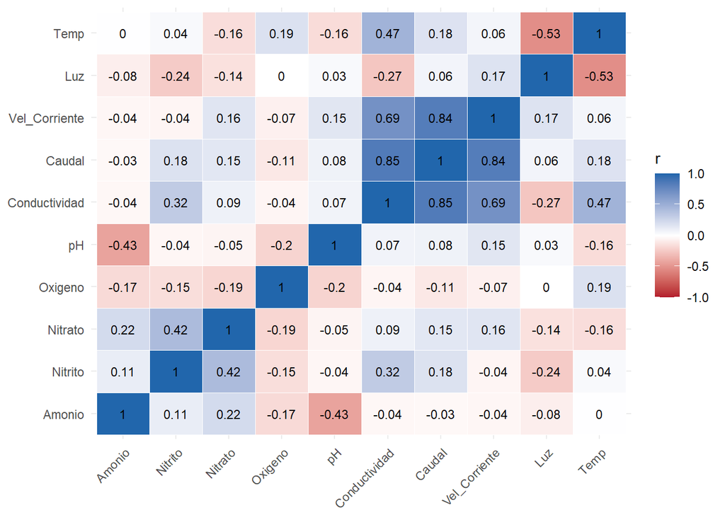

Figura 4: Mapa de calor de la matriz de correlación ambiental de microalgas (ggplot2).

```r
# De matriz a formato largo y mapa de calor con el valor de r
as.data.frame(as.table(r_X)) %>%
  ggplot(aes(x = Var1, y = Var2, fill = Freq)) +
  geom_tile(color = "white") +
  geom_text(aes(label = round(Freq, 2)), size = 3) +
  scale_fill_gradient2(low = "#B2182B",
                       mid = "white",
                       high = "#2166AC",
                       limits = c(-1, 1), name = "r") +
  labs(x = NULL, y = NULL) +
  theme_minimal() +
  theme(axis.text.x = element_text(angle = 45, hjust = 1))
```

**Para discutir:** el bloque conductividad–caudal–velocidad se resumiría en un mismo eje de un PCA (Taller 7). Si ese bloque se debe sobre todo a la diferencia entre tributarios, ¿qué se esperaría ver en el biplot cuando las muestras se colorean por tributario?

## 3. Diferencias entre tributarios

**Pregunta:** ¿Difieren los tributarios en su abundancia total y en sus variables ambientales?

**Código**

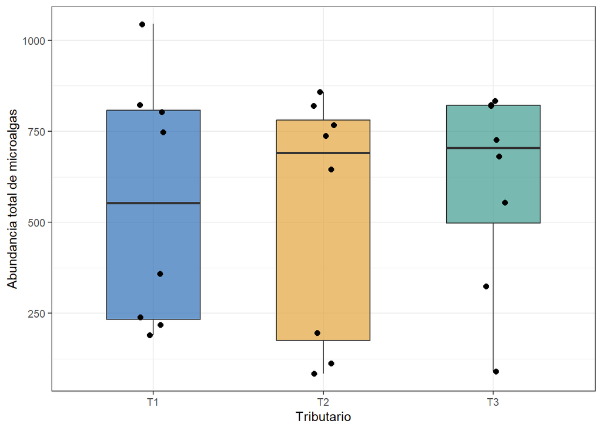

Figura 5: Abundancia total de microalgas por tributario (n = 8 visitas por tributario). Cada punto es una visita.

```r
# Abundancia total y riqueza por muestra de microalgas
alg_tot <- F_alg %>%
  mutate(Ab = rowSums(Y_alg), S = rowSums(Y_alg > 0))

# Cajas con los puntos encima
ggplot(alg_tot, aes(x = Tributario,
                    y = Ab, fill = Tributario)) +
  geom_boxplot(alpha = 0.7,
               width = 0.55,
               outlier.shape = NA) +
  geom_jitter(width = 0.08, size = 2) +
  scale_fill_manual(values = col_trib, guide = "none") +
  labs(x = "Tributario",
       y = "Abundancia total de microalgas") +
  theme_bw()
```

**Código**

```r
# Resumen por tributario
res_trib <- alg_tot %>%
  group_by(Tributario) %>%
  summarise(n = n(),
            Mediana = median(Ab),
            Mínimo = min(Ab),
            Máximo = max(Ab))

# Tabla del resumen
res_trib %>%
  kbl(booktabs = TRUE) %>%
  kable_classic(full_width = F) %>%
  row_spec(0, bold = TRUE)
```

| Tributario | n | Mediana | Mínimo | Máximo |
| --- | --- | --- | --- | --- |
| T1 | 8 | 552.5 | 190 | 1045 |
| T2 | 8 | 691.5 | 84 | 858 |
| T3 | 8 | 704.0 | 90 | 833 |

Los tributarios se solapan ampliamente en abundancia total (medianas de 552.5, 691.5, 704 individuos). Si difieren, la diferencia estará en **qué géneros** dominan, no en el total: ahí entra el análisis multivariado.

### Elipses por grupo: dos variables a la vez

Una elipse por grupo resume, en dos variables a la vez, dónde se ubica cada grupo y cuánto se dispersa. Es un anticipo de las elipses que se dibujan sobre los biplots de ordenación.

**Código**

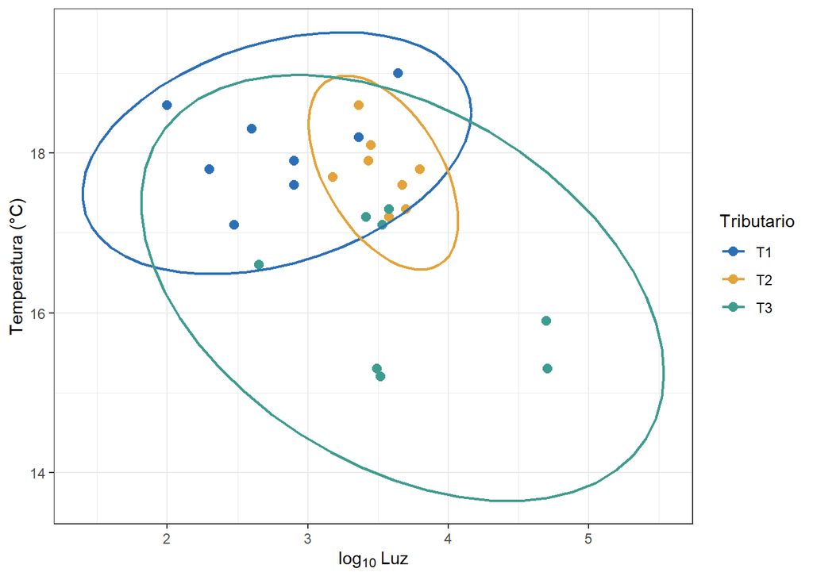

Figura 6: Temperatura frente a luz (escala log10) en los tres tributarios, con elipses de confianza del 95 %.

```r
# Dispersión con una elipse por tributario
ggplot(alg, aes(x = log10(Luz),
                y = Temp, color = Tributario)) +
  geom_point(size = 2.5) +
  stat_ellipse(level = 0.95, linewidth = 0.8) +
  scale_color_manual(values = col_trib) +
  labs(x = expression(log[10]~"Luz"),
       y = "Temperatura (°C)") +
  theme_bw()
```

**Código**

```r
# Visitas de T3: temperatura y luz
t3 <- alg %>% filter(Tributario == "T3")
```

T1 y T2 forman nubes compactas, con T2 como la más estrecha. La elipse de T3 es la más grande: en las visitas 1 a 5 el agua fue más fría (máximo de 16.6 °C) y en 2 visitas la luz superó los 10 000. Aquí los tributarios difieren menos en su **posición** que en su **dispersión** (el tamaño de la elipse).

**NotaPosición y dispersión**

Dos grupos pueden diferir en su posición (dónde está el centro), en su dispersión (qué tan grande es la elipse o la caja) o en ambas. La PERMANOVA es sensible a las dos cosas; por eso, si la dispersión cambia mucho entre grupos, se revisa con `betadisper` antes de interpretarla (Taller 10).

### Facetas: un panel por variable

**Código**

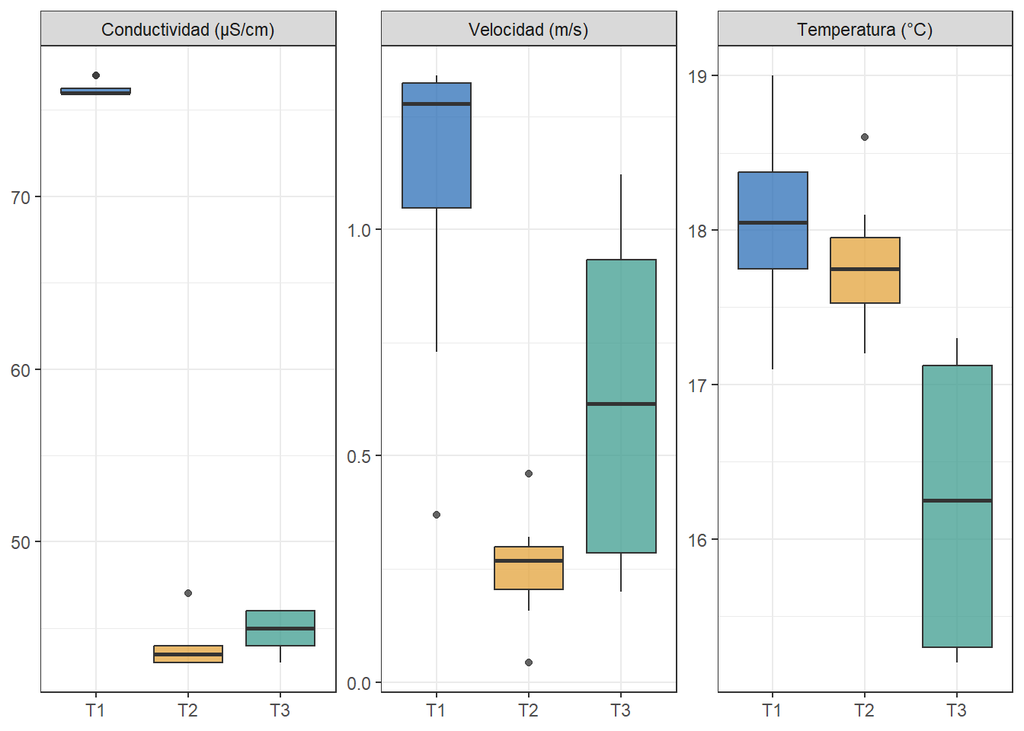

Figura 7: Conductividad, velocidad de corriente y temperatura en los tres tributarios (un panel por variable, cada uno con su propia escala).

```r
# De formato ancho a largo y un panel por variable
alg %>%
  select(Tributario, Conductividad, Vel_Corriente, Temp) %>%
  pivot_longer(-Tributario, names_to = "Variable", values_to = "Valor") %>%
  mutate(Variable = recode(Variable,
                           Conductividad = "Conductividad (μS/cm)",
                           Vel_Corriente = "Velocidad (m/s)",
                           Temp          = "Temperatura (°C)"),
         Variable = factor(Variable, levels = c("Conductividad (μS/cm)",
                                                "Velocidad (m/s)",
                                                "Temperatura (°C)"))) %>%
  ggplot(aes(x = Tributario, y = Valor, fill = Tributario)) +
  geom_boxplot(alpha = 0.75) +
  scale_fill_manual(values = col_trib, guide = "none") +
  facet_wrap(~ Variable, scales = "free_y") +
  labs(x = NULL, y = NULL) +
  theme_bw()
```

**Código**

```r
# Medianas por tributario
med_trib <- alg %>%
  group_by(Tributario) %>%
  summarise(across(c(Conductividad, Vel_Corriente, Temp), median))

# Tabla de medianas
med_trib %>%
  kbl(booktabs = TRUE, digits = 2) %>%
  kable_classic(full_width = F) %>%
  row_spec(0, bold = TRUE)
```

| Tributario | Conductividad | Vel_Corriente | Temp |
| --- | --- | --- | --- |
| T1 | 76.0 | 1.28 | 18.05 |
| T2 | 43.5 | 0.27 | 17.75 |
| T3 | 45.0 | 0.62 | 16.25 |

La conductividad (mediana de 76 μS/cm en T1, frente a 43.5 y 45) y la velocidad separan a **T1**; la temperatura es menor en **T3** (mediana de 16.25 °C).

## 4. Estudio de caso: escalas, ceros y colonización

En los tributarios del río Gaira se instalaron sustratos artificiales y se siguió la **colonización** de las microalgas perifíticas durante 8 semanas (visitas). Antes de ordenar estas matrices en los Talleres 7 a 9, se explora qué decisiones de datos exigen.

**Antes de correr el código**, se responde por escrito:

1. Mirando las escalas de X (la luz se mide en miles, la conductividad en decenas y el nitrito en décimas), ¿qué variable dominaría un PCA hecho con los datos crudos?
2. ¿Qué proporción de la matriz Y se espera en cero, y cuántos géneros concentrarán la mitad de los individuos?
3. Si la colonización avanza, ¿qué se espera de la abundancia total y de la riqueza a lo largo de las visitas? ¿Todos los géneros deberían aumentar?
4. ¿Los tributarios difieren más en su ambiente o en su abundancia total?

### Paso 1 — Escalas de la matriz ambiental (X)

**Código**

```r
# Resumen de cada variable ambiental
esc_X <- tibble(Variable = names(X_alg),
                Mínimo   = sapply(X_alg, min),
                Máximo   = sapply(X_alg, max),
                Media    = sapply(X_alg, mean),
                Varianza = sapply(X_alg, var)) %>%
  mutate(`% de la varianza total` = 100 * Varianza / sum(Varianza))

# Tabla de escalas
esc_X %>%
  kbl(booktabs = TRUE, digits = 3) %>%
  kable_classic(full_width = F) %>%
  row_spec(0, bold = TRUE)
```

| Variable | Mínimo | Máximo | Media | Varianza | % de la varianza total |
| --- | --- | --- | --- | --- | --- |
| Amonio | 0.028 | 5.905 | 0.684 | 1.60600e+00 | 0 |
| Nitrito | 0.147 | 1.176 | 0.535 | 5.40000e-02 | 0 |
| Nitrato | 0.386 | 5.242 | 1.443 | 1.59800e+00 | 0 |
| Oxigeno | 4.960 | 8.160 | 6.585 | 9.66000e-01 | 0 |
| pH | 6.430 | 9.630 | 8.083 | 7.93000e-01 | 0 |
| Conductividad | 43.000 | 77.000 | 55.000 | 2.36783e+02 | 0 |
| Caudal | 0.016 | 1.589 | 0.587 | 3.11000e-01 | 0 |
| Vel_Corriente | 0.043 | 1.340 | 0.662 | 2.13000e-01 | 0 |
| Luz | 100.000 | 51000.000 | 6506.208 | 1.86898e+08 | 100 |
| Temp | 15.200 | 19.000 | 17.358 | 1.09400e+00 | 0 |

**Código**

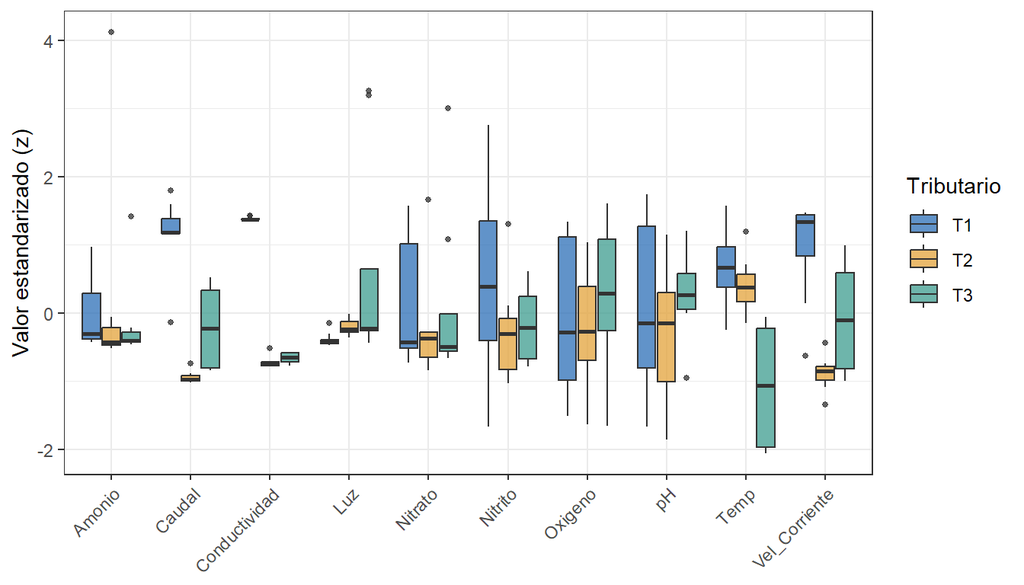

Figura 8: Variables ambientales de microalgas estandarizadas (media 0, desviación estándar 1). Después de estandarizar, todas quedan en la misma escala.

```r
# Estandarizar X y pasar a formato largo
X_est <- as_tibble(scale(X_alg)) %>%
  bind_cols(F_alg) %>%
  pivot_longer(Amonio:Temp, names_to = "Variable", values_to = "z")

# Cajas de las variables estandarizadas, por tributario
ggplot(X_est, aes(x = Variable,
                  y = z,
                  fill = Tributario)) +
  geom_boxplot(alpha = 0.75,
               outlier.size = 1) +
  scale_fill_manual(values = col_trib) +
  labs(x = NULL, y = "Valor estandarizado (z)") +
  theme_bw() +
  theme(axis.text.x = element_text(angle = 45, hjust = 1))
```

### Paso 2 — Dominancia y ceros en la matriz de especies (Y)

**Código**

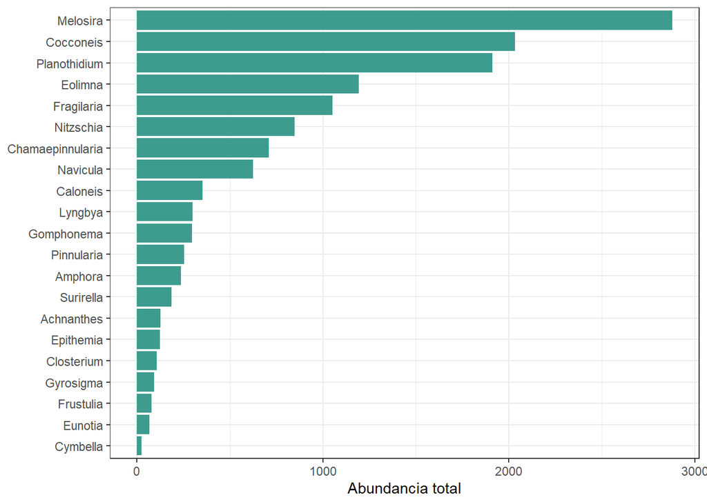

Figura 9: Abundancia total de cada género de microalgas en las 24 muestras.

```r
# Abundancia total por género, ordenada
dom_Y <- tibble(Genero = names(Y_alg),
                Total = colSums(Y_alg)) %>%
  arrange(desc(Total)) %>%
  mutate(Porcentaje = 100 * Total / sum(Total),
         Genero = factor(Genero, levels = rev(Genero)))

# Barras horizontales
ggplot(dom_Y, aes(x = Total, y = Genero)) +
  geom_col(fill = "#3E9C8F") +
  labs(x = "Abundancia total", y = NULL) +
  theme_bw()
```

**Código**

```r
# Proporción de ceros y concentración en los tres géneros dominantes
c(`% de celdas en cero` = round(100 * mean(as.matrix(Y_alg) == 0), 1),
  `% en los 3 géneros dominantes` = round(sum(dom_Y$Porcentaje[1:3]), 1))
```

```
          % de celdas en cero % en los 3 géneros dominantes
                         23.4                          50.5
```

### Paso 3 — La colonización a lo largo de las visitas

**Código**

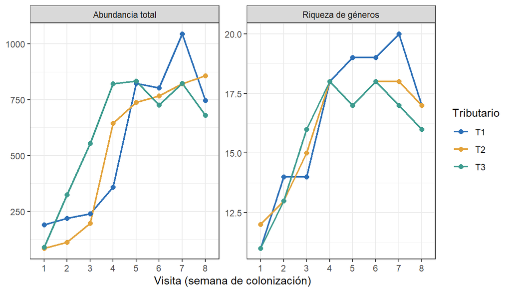

Figura 10: Abundancia total y riqueza de géneros de microalgas a lo largo de las 8 visitas, por tributario.

```r
# Abundancia total y riqueza por visita y tributario, en formato largo
alg_tot %>%
  pivot_longer(c(Ab, S), names_to = "Medida", values_to = "Valor") %>%
  mutate(Medida = recode(Medida, Ab = "Abundancia total", S = "Riqueza de géneros")) %>%
  ggplot(aes(x = Visita,
             y = Valor,
             color = Tributario,
             group = Tributario)) +
  geom_line(linewidth = 0.8) +
  geom_point(size = 2) +
  scale_color_manual(values = col_trib) +
  facet_wrap(~ Medida, scales = "free_y") +
  labs(x = "Visita (semana de colonización)", y = NULL) +
  theme_bw()
```

**Código**

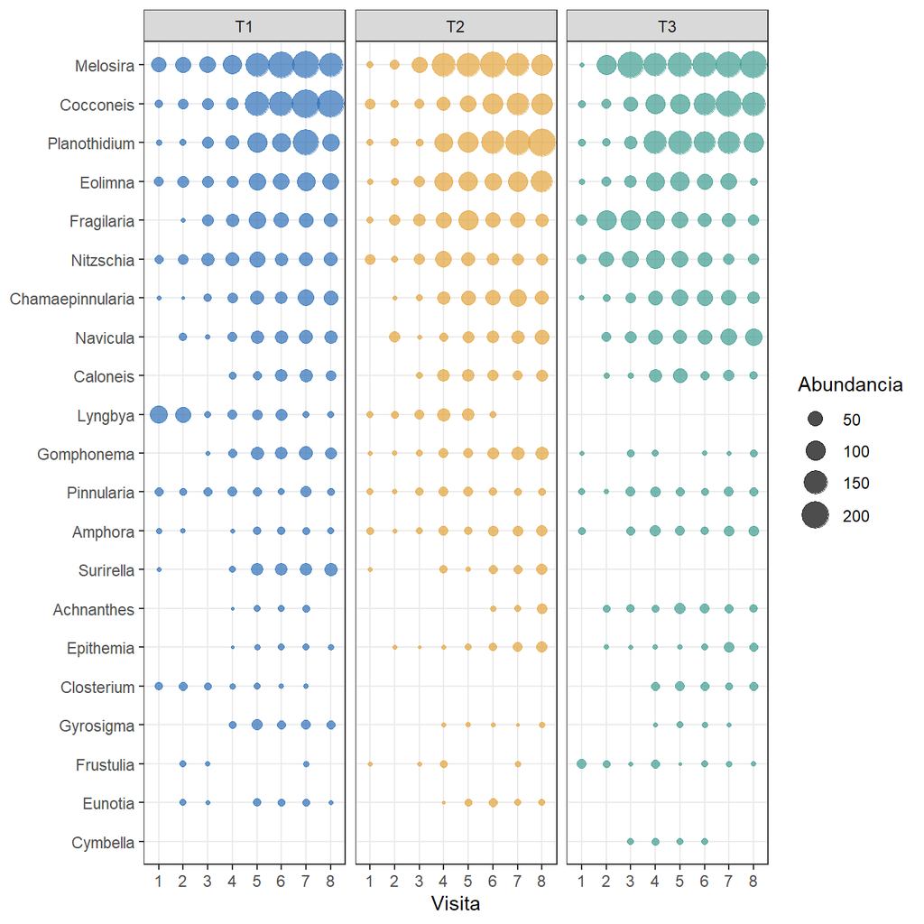

Figura 11: Burbujas de los 21 géneros de microalgas a lo largo de las visitas, por tributario (géneros ordenados por abundancia total).

```r
# Matriz Y en formato largo, unida a los factores
Y_largo <- bind_cols(F_alg, Y_alg) %>%
  pivot_longer(Fragilaria:Pinnularia,
               names_to = "Genero",
               values_to = "Abundancia")

# Burbujas por visita y tributario
Y_largo %>%
  filter(Abundancia > 0) %>%
  mutate(Genero = factor(Genero,
                         levels = levels(dom_Y$Genero))) %>%
  ggplot(aes(x = Visita,
             y = Genero,
             size = Abundancia,
             color = Tributario)) +
  geom_point(alpha = 0.7) +
  scale_size(range = c(0.5, 7)) +
  scale_color_manual(values = col_trib,
                     guide = "none") +
  facet_wrap(~ Tributario) +
  labs(x = "Visita", y = NULL) +
  theme_bw()
```

**Código**

```r
# Abundancia de un género pionero y uno tardío por visita (suma de los 3 tributarios)
suc <- Y_largo %>%
  filter(Genero %in% c("Lyngbya", "Surirella")) %>%
  group_by(Genero, Visita) %>%
  summarise(Total = sum(Abundancia), .groups = "drop") %>%
  pivot_wider(names_from = Visita,
              values_from = Total)

# Tabla
suc %>%
  kbl(booktabs = TRUE) %>%
  kable_classic(full_width = F) %>%
  row_spec(0, bold = TRUE) %>%
  add_header_above(c(" " = 1, "Visita" = 8))
```

| Genero | Visita 1 | Visita 2 | Visita 3 | Visita 4 | Visita 5 | Visita 6 | Visita 7 | Visita 8 |
| --- | --- | --- | --- | --- | --- | --- | --- | --- |
| Lyngbya | 78 | 60 | 20 | 50 | 47 | 33 | 6 | 5 |
| Surirella | 4 | 0 | 0 | 15 | 33 | 41 | 39 | 54 |

**NotaVerificación (desplegar después de responder)**

1. La luz va de 100 a 51 000 y concentra prácticamente toda la varianza de X: las otras nueve variables juntas suman apenas el 0.00013 %. Un PCA con los datos crudos (matriz de covarianza) sería, en la práctica, un eje de luz. Por eso el PCA de las variables ambientales se hace con los datos **estandarizados** (matriz de correlación), como en la Figura 8.
2. El 23.4 % de las celdas de Y son cero, y los tres géneros dominantes (*Melosira*, *Cocconeis* y *Planothidium*) concentran el 50.5 % de los individuos. Con muchos ceros y fuerte dominancia, la distancia euclidiana sobre conteos crudos no es adecuada: se transforma Y (p. ej., Hellinger) o se usa una distancia como Bray-Curtis (Talleres 8 y 9).
3. La abundancia media sube de 121 individuos en la visita 1 a 896 en la visita con el máximo, y la riqueza media pasa de 11.3 a 18.3 géneros. Es el patrón esperado en una colonización: el sustrato se va poblando y la riqueza se estabiliza después de las primeras semanas. No todos los géneros aumentan: *Lyngbya* (pionera) pasa de 78 individuos en la visita 1 a 5 en la 8, mientras que *Surirella* (tardía) pasa de 4 a 54. Ese **reemplazo** de géneros es un cambio de composición que el análisis multivariado debe captar.
4. Los tributarios se solapan en abundancia total (sección 3), pero se separan en varias variables ambientales (conductividad, velocidad, temperatura y luz; secciones 2 y 3). En el PCA del Taller 7 se espera que las muestras se agrupen por tributario.

**NotaDel exploratorio al PCA (Taller 7)**

Esta exploración deja tres decisiones tomadas para los siguientes talleres: (1) X se estandariza antes del PCA, (2) Y requiere una transformación o una distancia apropiada para abundancias con muchos ceros, y (3) la visita (semana de colonización) es una fuente de variación grande, como muestra el Paso 3, que habrá que tener en cuenta (como bloque en la PERMANOVA del Taller 10).

## Referencia

- Osorio Ávila, F. J., Rodríguez Barrios, J., & Montoya Moreno, Y. (2015). Sucesión de microalgas perifíticas en tributarios del río Gaira, Sierra Nevada de Santa Marta, Colombia. *Acta Biológica Colombiana*, 20(2), 119–131. https://doi.org/10.15446/abc.v20n2.41932